# ESM204_HW4

Annie Combs, Alissa Patterson, Michelle Geldin

May 16, 2022

```r
library(tidyverse)
library(janitor)
warming <- read_csv("warming.csv") %>%
  clean_names()
```

```
## * `` -> ...1
```

```r
damages <- read_csv("damages.csv")%>%
  clean_names()
model_damages <- lm(damages  ~ warming, data=damages)

summary(model_damages)
```

```
##
## Call:
## lm(formula = damages ~ warming, data = damages)
##
## Residuals:
##        Min         1Q     Median         3Q        Max
## -2.067e+14 -7.426e+13 -2.653e+13  5.674e+13  4.866e+14
##
## Coefficients:
##               Estimate Std. Error t value Pr(>|t|)
## (Intercept) -2.872e+14  9.415e+12  -30.51   <2e-16 ***
## warming      1.721e+14  2.478e+12   69.44   <2e-16 ***
## ---
## Signif. codes:  0 '***' 0.001 '**' 0.01 '*' 0.05 '.' 0.1 ' ' 1
##
## Residual standard error: 1.121e+14 on 554 degrees of freedom
## Multiple R-squared:  0.8969, Adjusted R-squared:  0.8968
## F-statistic:  4822 on 1 and 554 DF,  p-value: < 2.2e-16
```

## 1. Using damages.csv, estimate a quadratic damage function relating the dollar value of damages to the change in global mean temperature. Estimate a model with a zero intercept because damages by construction must equal zero when there is no climate change. Plot your estimated damage function, overlaid with a scatterplot of the underlying data.

```r
quadratic <- function(x) {y = x^2
return(y)}

warming2 <- warming^2

damages_lm <- lm(damages = warming + warming2, data = damages)
```

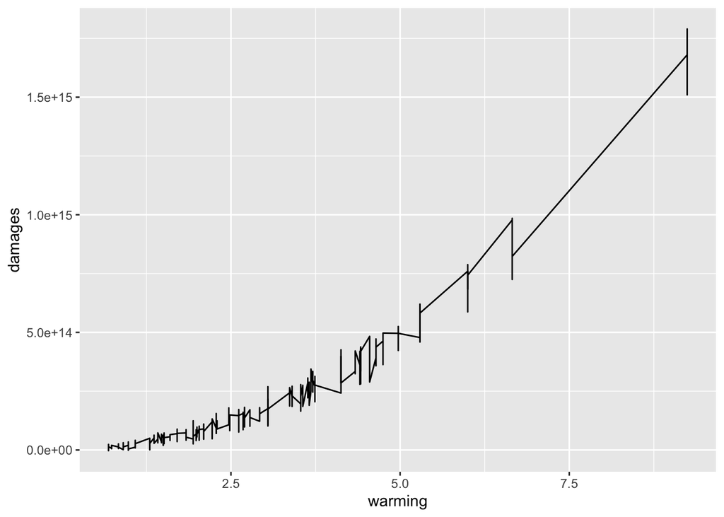

```r
damage_function <- quadratic(damages)

ggplot(damages_lm, aes(x = warming, y = damages))+
  geom_line()
```

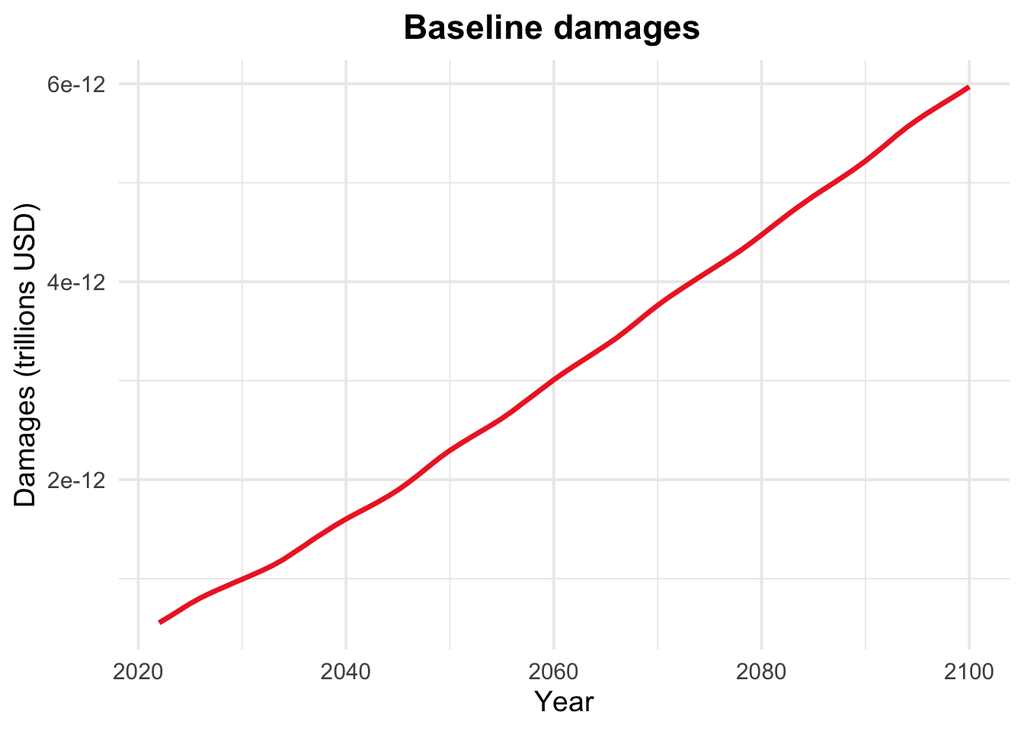

```r
# storing a function for damages from warming based on the quadratic model
damages <- function(warming) {
  damages <- damages_lm$coefficients[1]*warming + damages_lm$coefficients[2]*(warming^2)
  return(damages)
}

pulse <- warming %>%
  mutate(damages_baseline = damages(warming_baseline)) %>%
  mutate(damages_pulse = damages(warming_pulse)) %>%
  mutate(difference = damages_pulse - damages_baseline) %>%
  mutate(damage_per_ton = difference/35e+9)

p1 <- ggplot(data = pulse, aes(x = year, y = damages_baseline/1e+12)) +
  geom_line(size = 1.2, color = "firebrick2") +
  labs(x = "Year", y = "Damages (trillions USD)", title = "Baseline damages") +
  theme_minimal(14) +
  theme(plot.title = element_text(hjust = 0.48, face = "bold"))

p1
```

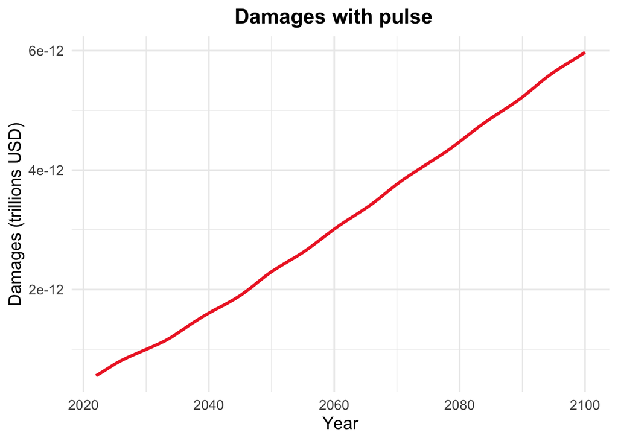

```r
p2 <- ggplot(data = pulse, aes(x = year, y = damages_pulse/1e+12)) +
  geom_line(size = 1.2, color = "firebrick2") +
  labs(x = "Year", y = "Damages (trillions USD)", title = "Damages with pulse") +
  theme_minimal(14) +
  theme(plot.title = element_text(hjust = 0.48, face = "bold"))

p2
```

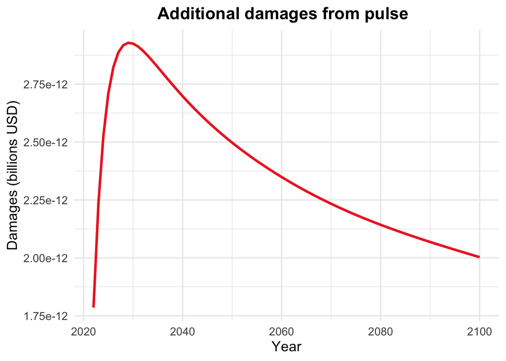

```r
p3 <- ggplot(data = pulse, aes(x = year, y = difference/1e+09)) +
  geom_line(size = 1.2, color = "firebrick2") +
  labs(x = "Year", y = "Damages (billions USD)", title = "Additional damages from pulse") +
  theme_minimal(14) +
  theme(plot.title = element_text(hjust = 0.48, face = "bold"))

p3
```

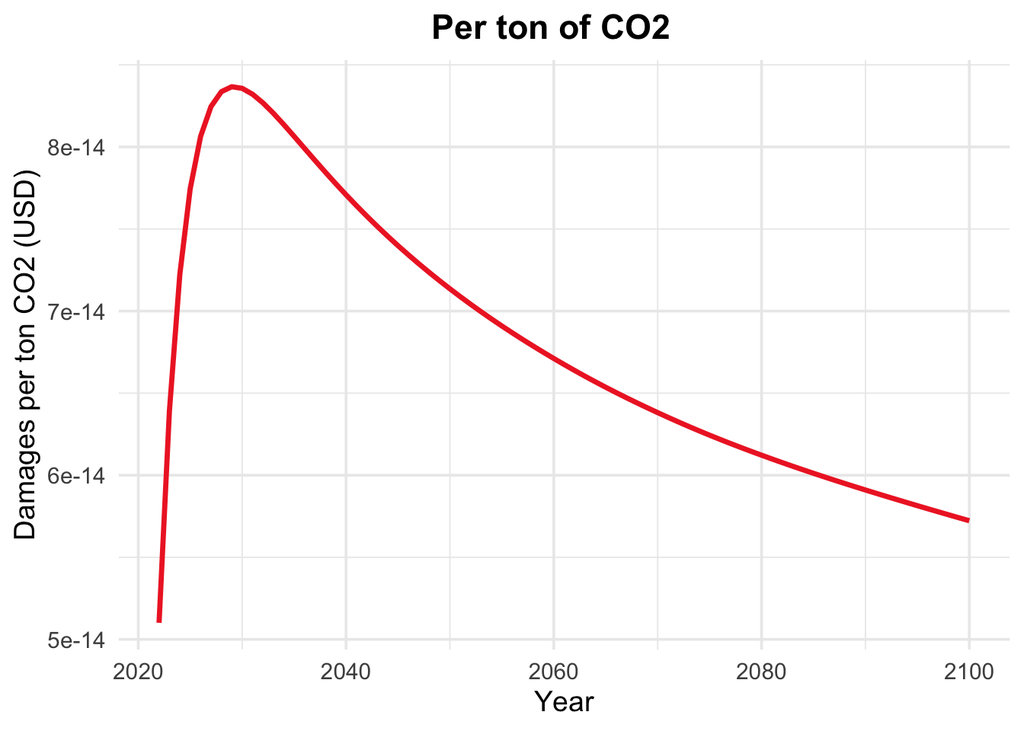

```r
p4 <- ggplot(data = pulse, aes(x = year, y = difference/35e+9)) +
  geom_line(size = 1.2, color = "firebrick2") +
  labs(x = "Year", y = "Damages per ton CO2 (USD)", title = "Per ton of CO2") +
  theme_minimal(14) +
  theme(plot.title = element_text(hjust = 0.48, face = "bold"))

p4
```

## 3. The SCC is the present discounted value of the stream of future damages caused by one additional ton of CO2. The Obama Administration used a discount rate of 3% to discount damages. Recently, New York State used a discount rate of 2%. Calculate and make a plot of the SCC (y-axis) against the discount rate (x-axis) for a reasonable range of discount rates. Explain the intuition for how the discount rate affects the SCC.

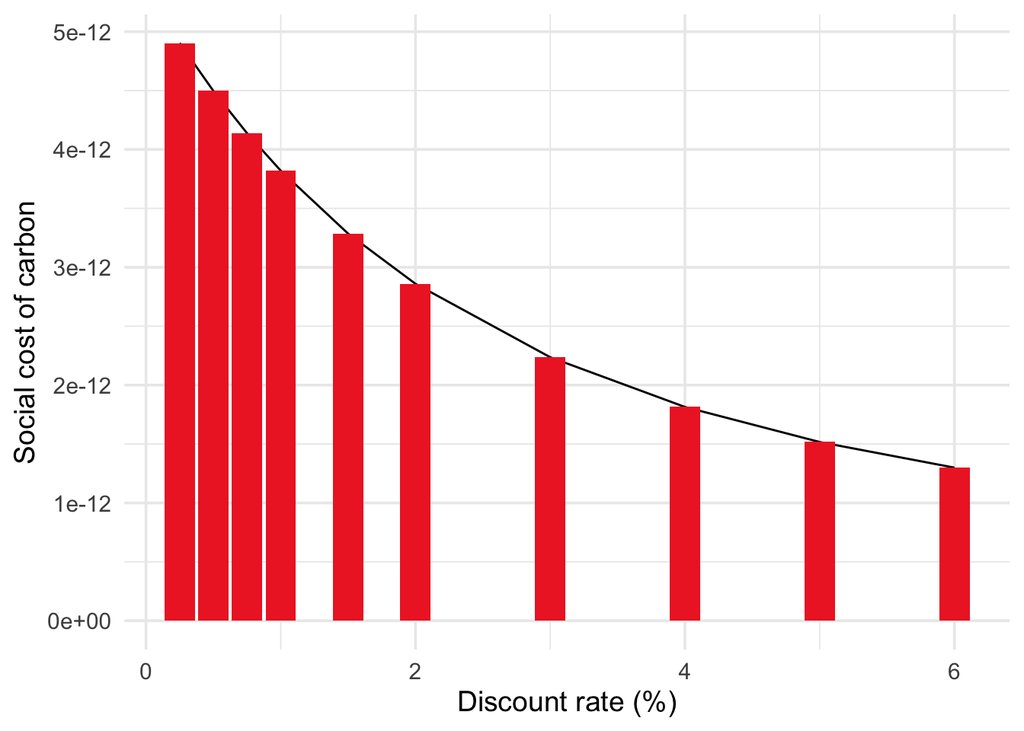

```r
scc <- pulse %>%
  mutate(years_into_future = year-2022) %>%
  mutate(scc_not_discounted = difference/35e+9) %>%
  mutate(dr0.25 = scc_not_discounted/(1.0025^years_into_future)) %>%
  mutate(dr0.5 = scc_not_discounted/(1.005^years_into_future)) %>%
  mutate(dr0.75 = scc_not_discounted/(1.0075^years_into_future)) %>%
  mutate(dr1 = scc_not_discounted/(1.01^years_into_future)) %>%
  mutate(dr1.5 = scc_not_discounted/(1.015^years_into_future)) %>%
  mutate(dr2 = scc_not_discounted/(1.02^years_into_future)) %>%
  mutate(dr3 = scc_not_discounted/(1.03^years_into_future)) %>%
  mutate(dr4 = scc_not_discounted/(1.04^years_into_future)) %>%
  mutate(dr5 = scc_not_discounted/(1.05^years_into_future)) %>%
  mutate(dr6 = scc_not_discounted/(1.06^years_into_future)) %>%
  mutate(dr2.1 = scc_not_discounted/(1.021^years_into_future))

scc0.025 <- sum(scc$dr0.25)
scc0.5 <- sum(scc$dr0.5)
scc0.75 <- sum(scc$dr0.75)
scc1 <- sum(scc$dr1)
scc1.5 <- sum(scc$dr1.5)
scc2 <- sum(scc$dr2)
scc2.1 <- sum(scc$dr2.1)
scc3 <- sum(scc$dr3)
scc4 <- sum(scc$dr4)
scc5 <- sum(scc$dr5)
scc6 <- sum(scc$dr6)
scc_vector <- c(scc0.025, scc0.5, scc0.75, scc1, scc1.5, scc2, scc3, scc4, scc5, scc6)
dr <- c(0.25, 0.5, 0.75, 1, 1.5, 2, 3, 4, 5, 6)
scc_table <- data.frame(scc_vector, dr)

ggplot(data = scc_table, aes(x = dr, y = scc_vector)) +
  geom_line() +
  geom_col(size = 3, fill = "firebrick2") +
  labs(x = "Discount rate (%)", y = "Social cost of carbon") +
  theme_minimal(14)
```

## 4. The National Academies of Sciences, Engineering, and Medicine advised the government in a 2017 report to use the Ramsey Rule when discounting within the SCC calculation: r = ρ + ηg Using ρ = 0.001, η = 2, and g = 0.01, what is the SCC? Locate this point on your graph from above.

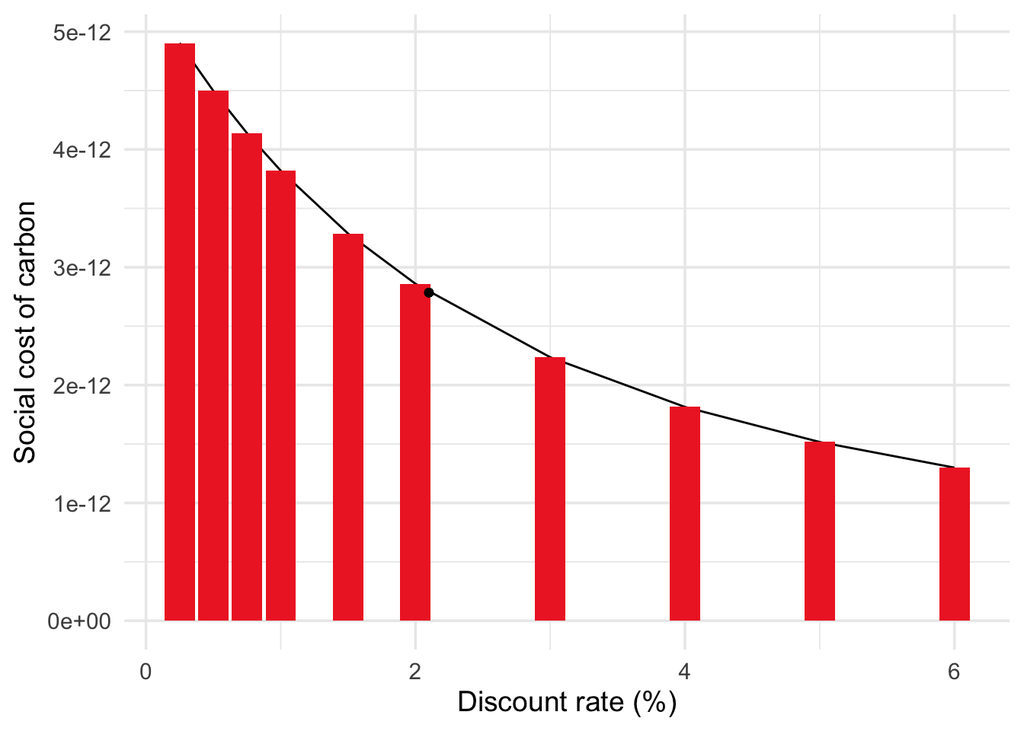

```r
# find the new r
#0.001 + 2(0.01) = 0.021
#r = 2.1%

# add point with new discount rate to the graph
ggplot(data = scc_table, aes(x = dr, y = scc_vector)) +
  geom_line() +
  geom_col(size = 3, fill = "firebrick2") +
  geom_point(x = 2.1, y = scc2.1, aes(labs("Ramsey Rule Discount Rate"))) +
  labs(x = "Discount rate (%)", y = "Social cost of carbon") +
  theme_minimal(14)
```

## 5. Now suppose there are two possible climate policies that can be pursued. Policy A is business as usual and Policy B is to take immediate and strong action on climate change. Use these facts

```r
# expected values
policy <- pulse %>%
  mutate(warming_policy_a = 1.5*warming_baseline) %>% # 0.5 chance of this occurring under A
  mutate(warming_policy_b = ifelse(year < 2050, warming_policy_a, 1.29)) %>% # 100% chance under Policy B
  mutate(damages_a = damages(warming_policy_a)) %>%
  mutate(damages_b = damages(warming_policy_b)) %>%
  mutate(years_into_future = year-2022) %>%
  mutate(damages_a_discounted = damages_a/(1.02^years_into_future)) %>%
  mutate(damages_b_discounted = damages_b/(1.02^years_into_future)) %>%
  mutate(damages_baseline_discounted = damages_baseline/(1.02^years_into_future))
# expected values
ev_a <- 0.5*sum(policy$damages_baseline_discounted) + 0.5*sum(policy$damages_a_discounted)
ev_b <- sum(policy$damages_b_discounted)
```

- If you undertake Policy A there are two possible outcomes. Either warming will occur as in the “baseline” (i.e. “no-pulse”) dataset above (this happens with probability 0.5) or warming each year will be 1.5 times that in the “baseline” dataset (with probability 0.5).
- Under Policy B, warming will continue until 2050 as in the “baseline” dataset, and then will stabilize at 1.29 degrees and stay that way forever.
- Society is risk neutral
- Use a discount rate of 2%

## What is the expected present value of damages up to 2100 under Policy A? What is the expected present value of damages up to 2100 under Policy B? Suppose undertaking Policy A costs zero and undertaking Policy B costs X. The total cost of a policy is the implementation cost plus expected damages. Make a plot of total cost of Policy A and total cost of Policy B against X. Suppose Congress wants to undertake the policy with the lower total cost. Use your graph to advise Congress.

## Damages

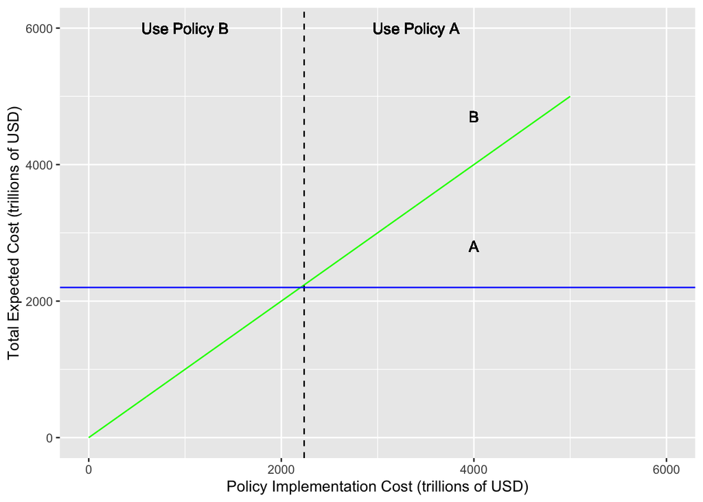

```r
# sequence for cost
cost <- seq(0, 5e15, by = 1e12)

cost_df <- data.frame(cost)

cost_compare <- cost_df %>%
  mutate(cost_b = ev_b + cost) %>%
  mutate(cost_a = ev_a)

# visualizing cost and damages of policy options
ggplot(data = cost_compare) +
  geom_line(aes(x = cost/1e12, y = cost_b/1e12), size = .5, color = "green") +
  labs(x = "Policy Implementation Cost (trillions of USD)", y = "Total Expected Cost (trillions of USD)") +
  geom_text(aes(x = 4000, y = 2800, label = "A")) +
  geom_text(aes(x = 4000, y = 4700, label = "B")) +
  geom_vline(xintercept = 2237, linetype = "dashed", size = .5) +
  geom_hline(yintercept = 2200, size = .5, color = "blue") +
  geom_text(aes(x = 1000, y = 6000, label = "Use Policy B")) +
  geom_text(aes(x = 3400, y = 6000, label = "Use Policy A")) +
  scale_y_continuous(limits = c(0, 6000)) +
  scale_x_continuous(limits = c(0, 6000))
```